```r
library(tidyverse)
library(scales)
library(forcats)
library(wordcloud)
library(tidytext)
library(lubridate)
```

```r
## load review data for las vegas hotels
load('data/vegas_hotels.rda')
```

### Find the most popular hotel in Las Vegas(most people go there and give high rating)

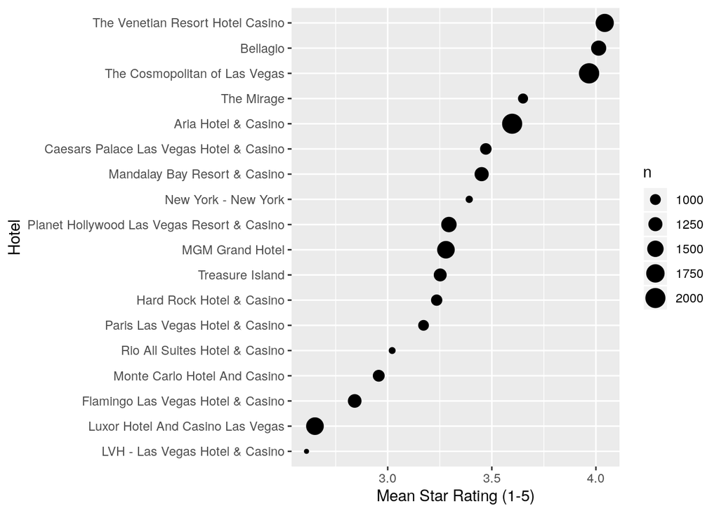

```r
reviews %>%
  left_join(select(business,business_id,name),
            by='business_id') %>%
  group_by(name) %>%
  summarize(n = n(),
            mean.star = mean(as.numeric(stars))) %>%
  arrange(desc(mean.star)) %>%
  ggplot() +
  geom_point(aes(x=reorder(name,mean.star),y=mean.star,size=n))+
  coord_flip() +
  ylab('Mean Star Rating (1-5)') +
  xlab('Hotel')
```

#### So The Venetian, Bellagio and The Cosmopolitan are clearly the highest rated hotels, while Luxor and LVH are the lowest rated. Ok, but what is behind these ratings? What are customers actually saying about these hotels? This is what we can hope to find through a text analysis.

### Count words about one hotel(Aria):

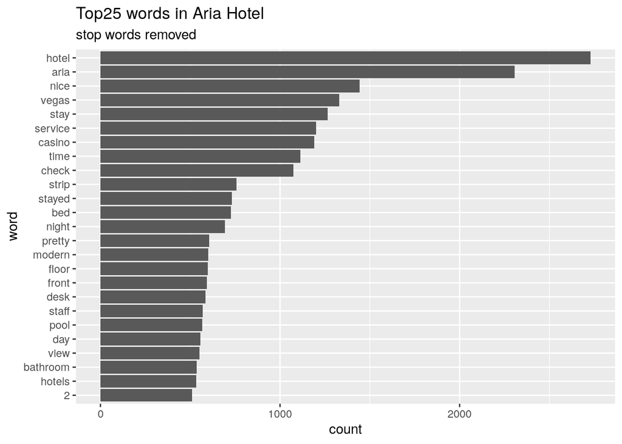

```r
## count each word in a document(sentences):split,count,antijoin
#exampleTidyNoStop= example%>%
  #unnest_tokens(word,text)%>%
  #count(doc_id,word) %>%
  #anti_join(stop_words,by='word')


## get reviews for Aria Hotel
aria.id <-  filter(business,
                   name=='Aria Hotel & Casino')$business_id
aria.reviews <- filter(reviews,
                       business_id==aria.id)

## doc-term matrix - tidy

AriaTidy=aria.reviews%>%
  select(review_id,text,stars)%>%
  unnest_tokens(word,text)

AriaFreqWords = AriaTidy%>%
  count(word)%>%
  anti_join(stop_words,by='word')

AriaFreqWords%>%
  top_n(25) %>%
  ggplot(aes(x=fct_reorder(factor(word),n),y=n))+geom_bar(stat='identity')+coord_flip()+
  labs(x='word',y="count",title='Top25 words in Aria Hotel',subtitle='stop words removed')
```

### Word clouds:

```r
#- visualizing a dtm

topWords <- AriaFreqWords %>%
  anti_join(stop_words) %>%
  top_n(100)
```

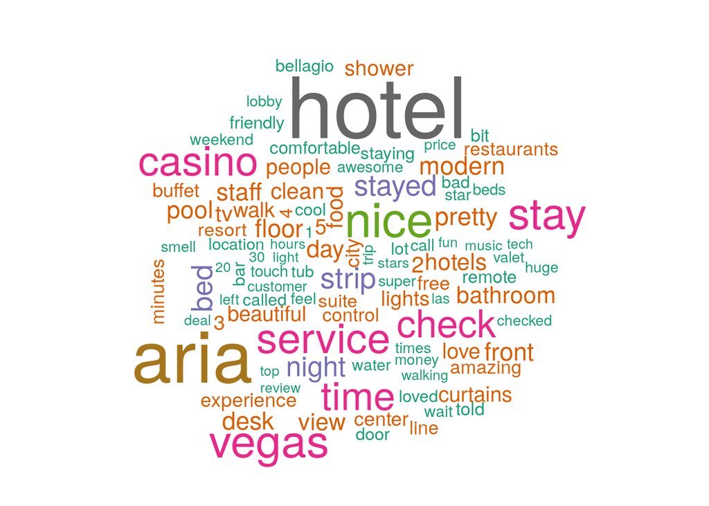

```r
plot=wordcloud(topWords$word,
           topWords$n,
           scale=c(5,0.5),
           colors=brewer.pal(8,"Dark2"))
```

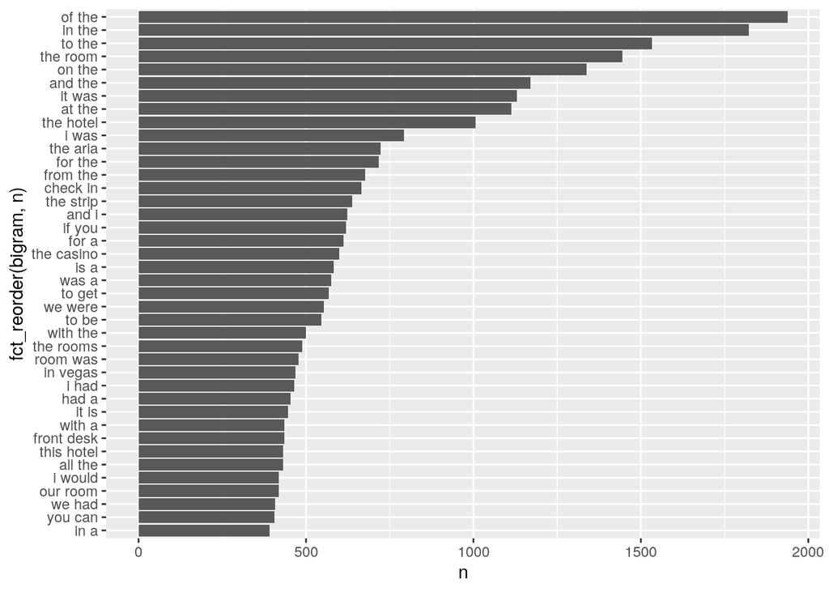

```r
## repeat with bi-grams

aria.reviews %>%
  select(review_id,text) %>%
  unnest_tokens(bigram,text,token="ngrams",n=2) %>%
  count(bigram) %>%
  top_n(40) %>%
  ggplot(aes(x=fct_reorder(bigram,n),y=n)) + geom_bar(stat='identity') +
  coord_flip()
```

#### Clean pretty and buffet are the features that attract people. But some words like “bad” should also arouse the attention of the hotel.

#### Next, we see what people say in different ratings.

### Count words in each star rating:

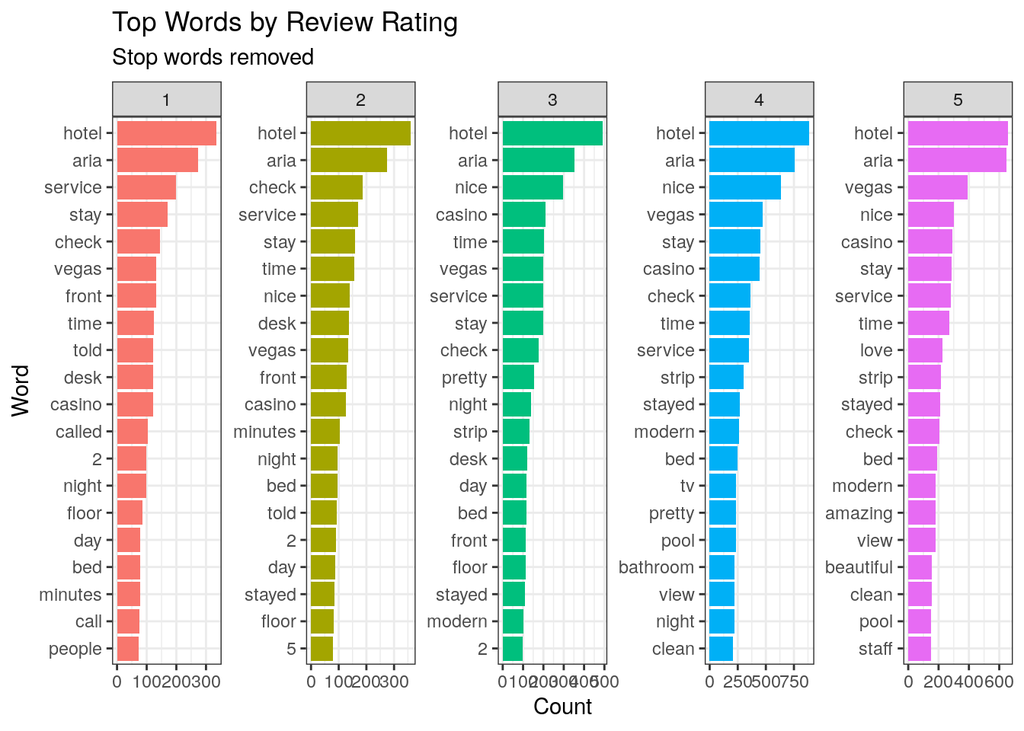

```r
## Top words by rating

AriaFreqWordsByRating <- AriaTidy %>%
  count(stars,word)

## for plotting (from https://github.com/dgrtwo/drlib/blob/master/R/reorder_within.R)
##Reorder a column before plotting with faceting, such that the values are ordered within each facet.

reorder_within <- function(x, by, within, fun = mean, sep = "___", ...) {
  new_x <- paste(x, within, sep = sep)
  stats::reorder(new_x, by, FUN = fun)
}

scale_x_reordered <- function(..., sep = "___") {
  reg <- paste0(sep, ".+$")
  ggplot2::scale_x_discrete(labels = function(x) gsub(reg, "", x), ...)
}

#compare with the code that did't use the function. The y label are blanks because words and scales are different.
#bystar=AriaFreqWordsByRating %>%anti_join(stop_words,by='word')%>% group_by(stars) %>% top_n(20) %>% arrange(stars,desc(n))
#bystar %>% ggplot(aes(x=fct_reorder(factor(word),n),y=n))+facet_wrap(~stars)+geom_bar(stat='identity')+coord_flip()

AriaFreqWordsByRating %>%
  anti_join(stop_words,by='word') %>%
  group_by(stars) %>%
  top_n(20) %>%
  ggplot(aes(x=reorder_within(word,n,stars),
             y=n,
             fill=stars)) +
  geom_bar(stat='identity') +
  coord_flip() +
  scale_x_reordered() +
  facet_wrap(~stars,scales = 'free',nrow=1) +
  theme_bw() +
  theme(legend.position = "none")+
  labs(title = 'Top Words by Review Rating',
       subtitle = 'Stop words removed',
       x = 'Word',
       y = 'Count')
```

#### Obviously, check,service,font,minutes… These keys words appear most frequently in the low rating views. The customers were likely to complain about the wait time when checkin/checkout. This give the hotel some idea that it should improve its efficiency. Otherwise, it will worsen its rating on the website.

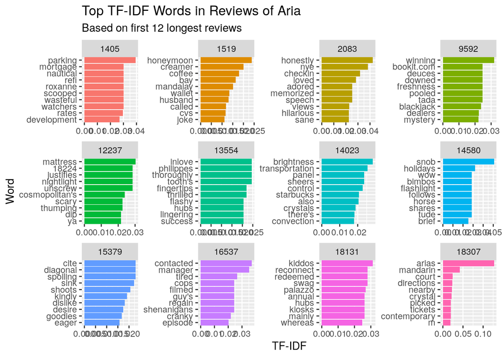

```r
tidyReviews <- aria.reviews %>%
  select(review_id,text) %>%
  unnest_tokens(word, text) %>%
  count(review_id,word)

minLength <- 200  # focus on long reviews
tidyReviewsLong <- tidyReviews %>%
  group_by(review_id) %>%
  summarize(length = sum(n)) %>%
  filter(length >= minLength)

tidyReviewsTFIDF <- tidyReviews %>%
  filter(review_id %in% tidyReviewsLong$review_id) %>%
  bind_tf_idf(word,review_id,n) %>% #word in each review 's n
  group_by(review_id) %>%
  arrange(desc(tf_idf)) %>%
  slice(1:10) %>% # get top 10 words in terms of tf-idf
  ungroup() %>%
  mutate(xOrder=n():1) %>%  # for plotting
  inner_join(select(aria.reviews,review_id,stars),by='review_id')  # get star ratings


nReviewPlot <- 12
plot.df <- tidyReviewsTFIDF %>%
  filter(review_id %in% tidyReviewsLong$review_id[1:nReviewPlot])

plot.df %>%
  mutate(review_id_n = as.integer(review_id)) %>%
  ggplot(aes(x=xOrder,y=tf_idf,fill=factor(review_id_n))) +
  geom_bar(stat = "identity", show.legend = FALSE) +
  facet_wrap(~ review_id_n,scales='free') +
  scale_x_continuous(breaks = plot.df$xOrder,
                     labels = plot.df$word,
                     expand = c(0,0)) +
  coord_flip()+
  labs(x='Word',
       y='TF-IDF',
       title = 'Top TF-IDF Words in Reviews of Aria',
       subtitle = paste0('Based on first ',
                         nReviewPlot,
                         ' longest reviews'))+
  theme(legend.position = "none")
```

### Word frequencey change with time. This gives insights about the seasonality of branding.

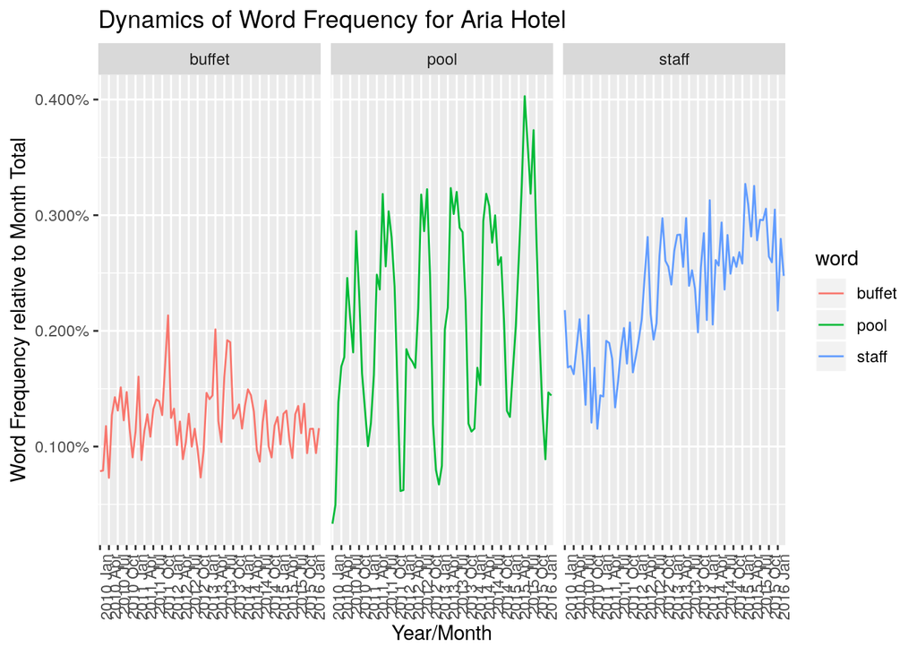

```r
## Aria on Tripadvisor reviews
aria <- read_rds('data/AriaReviewsTrip.rds') %>%
  rename(text = reviewText)

meta.data <- aria %>%
  select(reviewID,reviewRating,date,year.month.group)

ariaTidy <- aria %>%
  select(reviewID,text) %>%
  unnest_tokens(word,text) %>%
  count(reviewID,word) %>%
  inner_join(meta.data,by="reviewID")

## word frequency over time

total.terms.time <- ariaTidy %>%
  group_by(year.month.group) %>%
  summarize(n.total=sum(n))

## for the legend
a <- 1:nrow(total.terms.time)
b <- a[seq(1, length(a), 3)]


words_want_know=c("pool","staff","buffet")
ariaTidy %>%
  filter(word %in% words_want_know) %>%
  group_by(word,year.month.group) %>%
  summarize(n = sum(n)) %>%
  left_join(total.terms.time, by='year.month.group') %>%
  ggplot(aes(x=year.month.group,y=n/n.total,color=word,group=word)) +
  geom_line() +
  facet_wrap(~word)+
  theme(axis.text.x = element_text(angle = 90, hjust = 1))+
  scale_x_discrete(breaks=as.character(total.terms.time$year.month.group[b]))+
  scale_y_continuous(labels=percent)+xlab('Year/Month')+
  ylab('Word Frequency relative to Month Total')+
  ggtitle('Dynamics of Word Frequency for Aria Hotel')
```

#### We see three different patterns for the relative frequencies: “buffet” is used in a fairly stable manner over this time period, while “pool” displays clear seasonality, rising in popularity in the summer months. Finally, we see an upward trend in the use of “staff”.

```r
## same but for different satisfaction segments
aria.tidy2 <- ariaTidy %>%
  mutate(year = year(date),
         satisfaction = fct_recode(factor(reviewRating),
                                   "Not Satisfied"="1",
                                   "Not Satisfied"="2",
                                   "Neutral"="3",
                                   "Neutral"="4",
                                   "Satisfied"="5"))

total.terms.rating.year <- aria.tidy2 %>%
  group_by(satisfaction,year) %>%
  summarize(n.total = sum(n))


words_want_know=c("pool","staff","buffet","food","wait","casino","line","check","clean")

t=aria.tidy2 %>%
  filter(word %in% words_want_know) %>%
  group_by(satisfaction,year,word) %>%
  summarize(n = sum(n)) %>%
  left_join(total.terms.rating.year, by=c('year','satisfaction')) %>%
  ggplot(aes(x=year,y=n/n.total,color=satisfaction,group=satisfaction)) +
  geom_line(size=1,alpha=0.25) + geom_point() +
  facet_wrap(~word,scales='free')+
  theme(axis.text.x = element_text(angle = 90, hjust = 1))+xlab('Year')+
  scale_y_continuous(labels=percent)+
  ylab('Word Frequency relative to Month Total')+
  labs(title='Dynamics of Word Frequency for Aria Hotel',
       subtitle='Three Satisfaction Segments')
```